# CCK81 variant calling: Data exploration

Emiel

2023-06-09

```r
library(ggplot2)
library(dplyr)
library(BSgenome.Hsapiens.UCSC.hg38)
library(GenomicRanges)
library(MutationalPatterns)
```

# Variant calling

Variant calling was performed as follows;

- Download CCK81 compressed .fq files
- Download Ensembl reference genome
- Quality control using [FASTQC](https://www.bioinformatics.babraham.ac.uk/projects/fastqc/)
- Read alignment to reference using STAR
- Variant calling on .BAM using Mutect2
- Annotation of variant calls using [ANNOVAR](https://annovar.openbioinformatics.org/en/latest/)

An example bash workflow can be found on [GitHub](https://github.com/eevenepo/myNEO/blob/main/variant_calling/variant_calling_pipeline.sh).

# Data exploration

Load preprocessed data.

```r
CCK81_snv <- readRDS("/home/labgroups/ccgg/temp_nosnapshot/emiel/myNEO/CCK81_snv.rds")
CCK81 <- readRDS("/home/labgroups/ccgg/temp_nosnapshot/emiel/myNEO/CCK81.rds")
```

## Mutation types

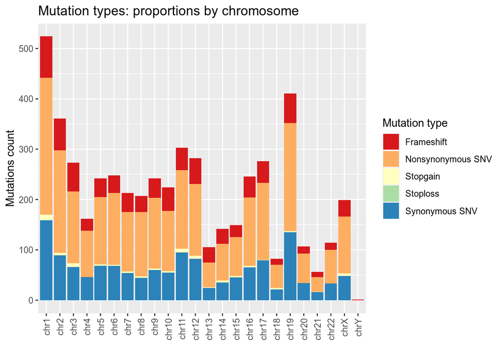

```r
# Get mutation counts
count_table <- CCK81 %>%
               group_by(CHROM, var_effect) %>%
               count()

# Order by chromosome (written out due to mix of numbers and letters)
count_table$CHROM <- factor(count_table$CHROM,
                      levels = c("chr1",
                                 "chr2",
                                 "chr3",
                                 "chr4",
                                 "chr5",
                                 "chr6",
                                 "chr7",
                                 "chr8",
                                 "chr9",
                                 "chr10",
                                 "chr11",
                                 "chr12",
                                 "chr13",
                                 "chr14",
                                 "chr15",
                                 "chr16",
                                 "chr17",
                                 "chr18",
                                 "chr19",
                                 "chr20",
                                 "chr21",
                                 "chr22",
                                 "chrX",
                                 "chrY"))

# Visualize
ggplot(count_table,
       aes(x=CHROM,
           y=n,
           fill=var_effect))+
       geom_bar(position="stack", stat="identity")+
       scale_fill_brewer(palette="Spectral") +
       labs(x = '',
            y = 'Mutations count',
            fill = 'Mutation type',
            title = 'Mutation types: proportions by chromosome')+
      theme(axis.text.x = element_text(angle = 90, vjust = 0.5, hjust=1))
```

Several observations can be made. Larger chromosomes (e.g. 1 and 2) carry more mutations, which is to be expected due to their size. Additionally, mutation counts in sex chromosomes suggest CCK81 cells originate from a female patient, which is [correct](https://depmap.org/portal/cell_line/ACH-000963?tab=overview).

Remarkably, a single frameshift mutation is mapped to the Y-chromosome; this is likely due to a single incorrectly mapped read.

## SNV mutational signature

Mutational signatures are characteristic patterns of mutations caused by various biological processes (exposure to mutagens, replication errors etc.). They are highly relevant to cancer research, and are often accounted for when investigating possible neoantigen depletion ([Van den Eynden et al. 2019](https://www.nature.com/articles/s41588-019-0532-6)).

```r
# Save snv as GenomicRanges() object
gr <- makeGRangesFromDataFrame(CCK81_snv,
                               start.field = "start",
                               end.field = "stop",
                               seqnames.field = "CHROM")
genome(gr) <- 'hg38'

# Add mutations
mcols(gr)$ref <- CCK81_snv$ref
mcols(gr)$alt <- CCK81_snv$alt
```

We visualize the trinucleotide pattern.

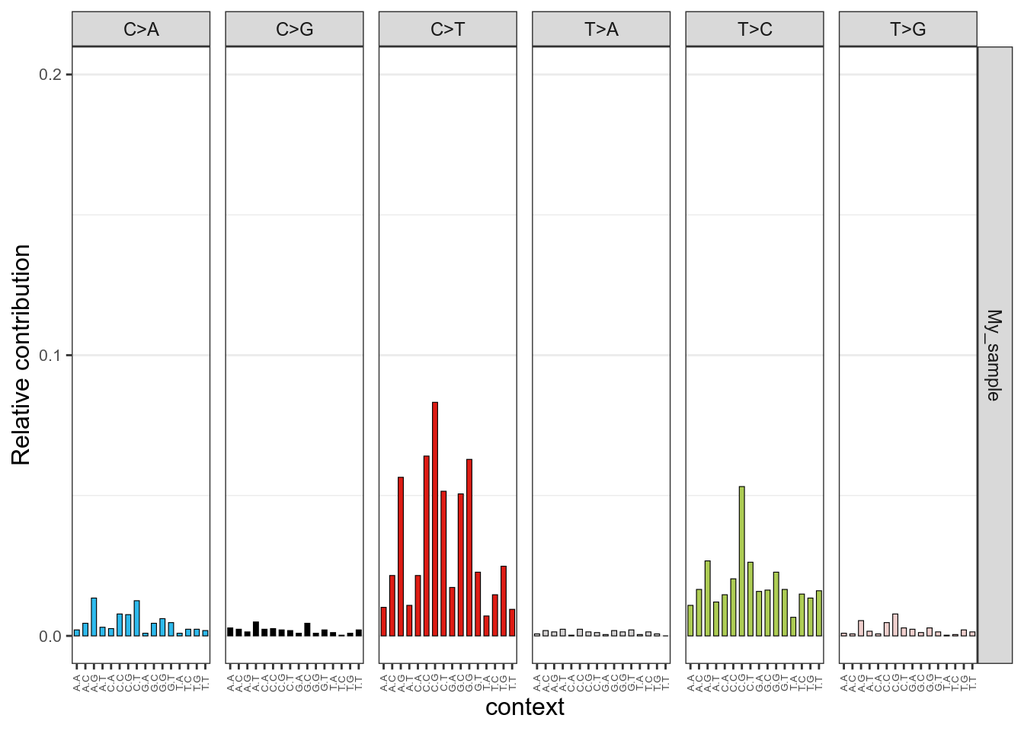

```r
ref_genome <- 'BSgenome.Hsapiens.UCSC.hg38'
mut_mat <- mut_matrix(gr, ref_genome)
plot_96_profile(mut_mat)
```

There appears to be an extremely high contribution of C>T and T>C mutations. We can compare this pattern to known COSMIC signatures.

```r
# COSMIC signatures
signatures <- get_known_signatures()

# Compare to CCK81 pattenrn
cos_sim_signatures <- data.frame(t(cos_sim_matrix(mut_mat, signatures)))
cos_sim_signatures <- cos_sim_signatures %>%
  tibble::rownames_to_column(var = "signature")

# Order by increasing cosine similarity
cos_sim_signatures <- cos_sim_signatures[order(-cos_sim_signatures$My_sample),]
```

Visualize the similarity between the CCK81 pattern and COSMIC signatures.

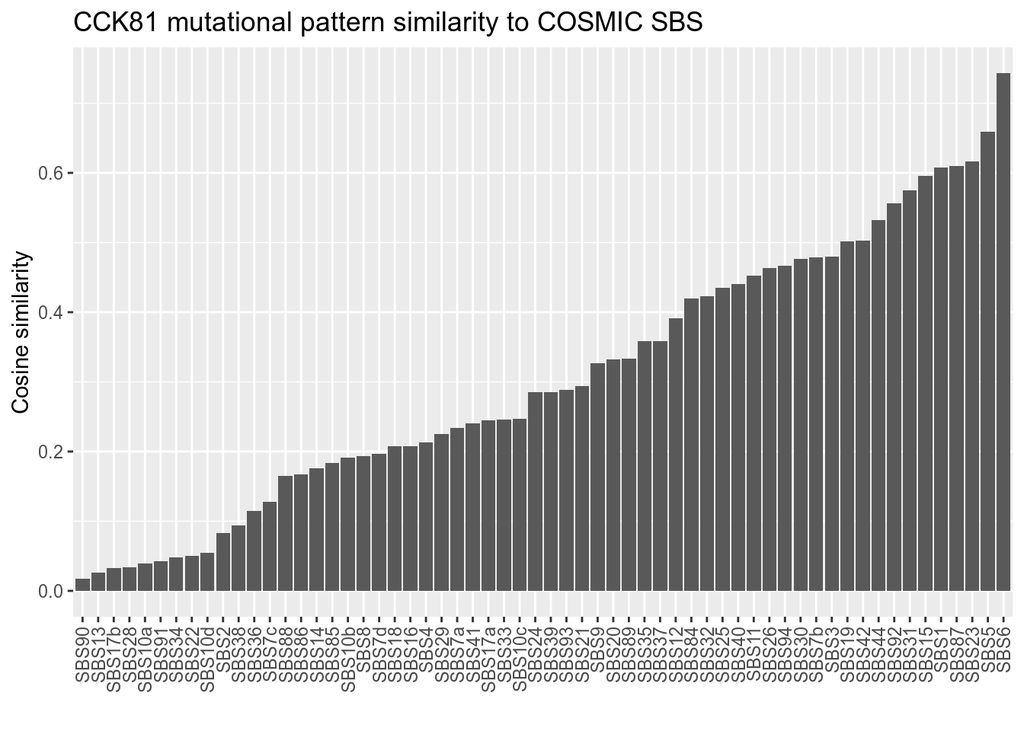

```r
ggplot(cos_sim_signatures,
       aes(x=reorder(signature, My_sample),
           y= My_sample)) +
       geom_bar(stat="identity")+
       labs(x = '',
            y = 'Cosine similarity',
            title = 'CCK81 mutational pattern similarity to COSMIC SBS')+
      theme(axis.text.x = element_text(angle = 90, vjust = 0.5, hjust=1))
```

Similarity to most signatures is quite low. We briefly looked into [SBS6](https://cancer.sanger.ac.uk/signatures/sbs/sbs6/), which may be associated with defective DNA mismatch repair and microsatellite instability (MSI), processes which are active in intestinal adenocarcinoma in CCK81.

## Indels

We briefly illustrate the insertions and deletions.

```r
insertions <- CCK81 %>%
  filter(grepl("^[-]", Nchange)) %>%
  mutate(Insertion_length =nchar(Nchange) - 2) %>%
  count(Insertion_length) %>%
  arrange(as.numeric(n))

deletions <- CCK81 %>%
  filter(grepl("^[+]", Nchange)) %>%
  mutate(Deletion_length = nchar(Nchange) - 2) %>%
  count(Deletion_length) %>%
  arrange(n)

print(insertions)
```

```
##   Insertion_length   n
## 1                5   1
## 2               29   1
## 3               93   1
## 4              148   1
## 5                4   3
## 6                2  39
## 7                1 644
```

```r
print(deletions)
```

```
##   Deletion_length   n
## 1              41   1
## 2              74   1
## 3               4   2
## 4               2   9
## 5               1 159
```

The vast majority of indels only insert or delete a single nucleotide; longer indels are relatively rare.